# Diagnostics: is the null result real?

Specification audit, local projections, and a power analysis

Amir Azlan, University of Illinois Urbana-Champaign

November 18, 2026

The distributed-lag results in `05` and `06` show no significant effect of either exposure channel on county unemployment, with very wide confidence bands. This file asks whether that is a property of the data or an artefact of the specification. It finds that the cumulation step in `05` is invalid for a monthly-change regressor, tries local projections as a fix, and finds that those fail a stability test as well (section 5). The specification that fits this shock is in `08_event_study_levels.Rmd`.

# 0. The problem with cumulating a flow regressor

`05` estimates

$$u_{c,t}=\alpha_{c,\text{month}}+\gamma_t+\sum_{m=-G}^{M}\beta_m\,\Delta
IP_{c,t-m}+\dots$$

and reports $\delta_k=\sum_{m=-G}^{k}\beta_m$ as “the cumulative effect of a permanent unit increase in exposure.” That identity holds when the regressor is the **level** of treatment (Schmidheiny & Siegloch). Our regressor is the monthly **change**, so the response to a one-time permanent tariff increase is $\beta_k$ itself, and cumulating it describes a different experiment: exposure rising by one unit *every month, forever*.

```r
# Synthetic check: permanent exposure step of 5 at t=0; true effect 0.1 per unit, arriving at h=3.
Zlev <- c(rep(0, 6), rep(5, 18))                 # exposure level
dZ   <- c(0, diff(Zlev))                          # flow: a single spike
u    <- 0.1 * shift(Zlev, 3, fill = 0)            # truth: flat at 0.5 from h=3 onward
data.table(h = -3:5, exposure_level = Zlev[4:12], exposure_flow = dZ[4:12],
           true_effect = u[4:12])
```

| h | exposure_level | exposure_flow | true_effect |
| --- | --- | --- | --- |
| -3 | 0 | 0 | 0.0 |
| -2 | 0 | 0 | 0.0 |
| -1 | 0 | 0 | 0.0 |
| 0 | 5 | 5 | 0.0 |
| 1 | 5 | 0 | 0.0 |
| 2 | 5 | 0 | 0.0 |
| 3 | 5 | 0 | 0.5 |
| 4 | 5 | 0 | 0.5 |
| 5 | 5 | 0 | 0.5 |

Fitting the flow specification to this data recovers $\beta_3=\beta_4=\dots=0.1$, which is correct. Cumulating gives $0.1, 0.2, 0.3,\dots$ — a linear climb where the truth is flat. The RIC panel in `05` has exactly that shape, and its confidence band widens with $k$ because the variance of a 13-term sum accumulates. Both are expected artefacts.

**Second problem.** The tariff shock is close to a single event (spring 2025) inside a 24-month window. The lags of a one-time spike are near-collinear by construction, date fixed effects absorb the common time path, and 26 coefficients are asked of cross-county composition differences alone. Section 3 quantifies how little independent variation remains.

**A first attempt at a fix** is one regression per horizon with a single shock term: local projections. Section 5 tests whether that is enough.

# 1. Rebuild the panel, with exposure in levels as well as flows

```r
G <- 6; M <- 9        # six placebo horizons; two is too thin to rest a result on
base_year  <- 2024
est_start  <- as.Date("2024-01-01")
last_month <- as.Date("2026-03-01")

ce <- fread(file.path(proc, "county_exposure_monthly.csv.gz"), colClasses = list(character = "fips"))
ce[, date := as.Date(date)]

laus <- fread(file.path(proc, "laus_county_unemployment.csv"),
              colClasses = list(character = c("fips", "state_fips")))
laus[, date := as.Date(date)]; setorder(laus, fips, date)

qpath <- c(file.path(proc, sprintf("qcew_county_industry_%d.parquet", base_year)),
           file.path(proc, sprintf("qcew_county_industry_%d.csv.gz", base_year)))
qpath <- qpath[file.exists(qpath)][1]
q <- if (grepl("parquet$", qpath)) as.data.table(arrow::read_parquet(qpath)) else
  fread(qpath, colClasses = list(character = c("area_fips", "agglvl_code", "own_code")))
q[, `:=`(area_fips = as.character(area_fips), agglvl_code = as.character(agglvl_code),
         own_code = as.character(own_code))]
Nc <- q[agglvl_code == "70" & own_code == "0", .(fips = area_fips, N_c = emp_avg)]

# Exposure ends with the customs panel (March 2026), but LAUS runs to September 2026.
# Extending the grid to the end of LAUS keeps the long-horizon outcomes that would
# otherwise be dropped: at h = 9, shocks were previously usable only through June 2025.
# Tariff changes are treated as zero after the customs panel ends - an assumption, and
# the reason shock months are capped at last_month in run_lp below.
outcome_end <- max(laus$date)
grid_dates <- seq(as.Date("2023-01-01"), outcome_end, by = "month")
P <- CJ(fips = unique(ce$fips), date = grid_dates)
P <- merge(P, ce, by = c("fips", "date"), all.x = TRUE)
P[is.na(dIP), dIP := 0]; P[is.na(dRIC), dRIC := 0]
setorder(P, fips, date)

# LEVEL of cumulative exposure (the analogue of AT2026's Local IP / Local RIC)
P[, `:=`(IP_lvl = cumsum(dIP), RIC_lvl = cumsum(dRIC)), by = fips]

P <- merge(P, laus[, .(fips, date, unemp_rate)], by = c("fips", "date"), all.x = TRUE)
P <- merge(P, Nc, by = "fips")
P[, `:=`(state = substr(fips, 1, 2), cal_month = month(date))]
setorder(P, fips, date)

cat(sprintf("Panel: %s rows, %s counties, %s to %s\n", format(nrow(P), big.mark = ","),
            format(uniqueN(P$fips), big.mark = ","), min(P$date), max(P$date)))
```

```
## Panel: 141,435 rows, 3,143 counties, 2023-01-01 to 2026-09-01
```

# 2. Local projections

For each horizon $h$,

$$u_{c,t+h}-u_{c,t-1}=\alpha_c+\gamma_t+\theta^{IP}_h\,\Delta
IP_{c,t}+\theta^{RIC}_h\,\Delta
RIC_{c,t}+\sum_{l=1}^{L}\text{controls}_{c,t-l}+e_{c,t,h}$$

$\theta_h$ **is** the effect at horizon $h$ — no cumulation. Negative $h$ are placebo horizons and test pre-trends. Each horizon is its own regression, so the lag terms never compete with one another for identification.

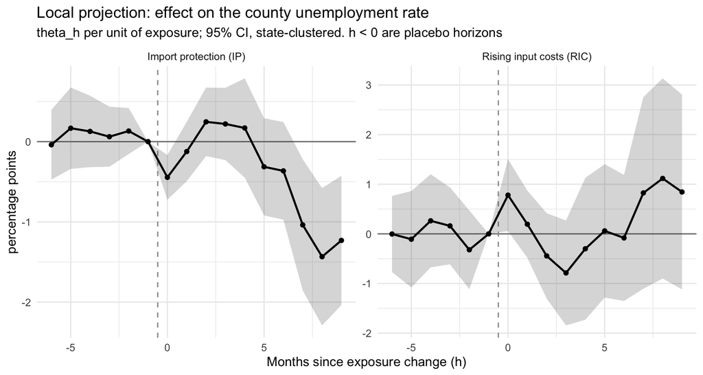

```r
L_CTRL <- 3   # control lags

for (l in 1:L_CTRL) {
  P[, paste0("dIP_l",  l) := shift(dIP,  l), by = fips]
  P[, paste0("dRIC_l", l) := shift(dRIC, l), by = fips]
}
# lagged outcome changes, built deep enough for the shifted placebo controls below
for (l in 1:(G + L_CTRL)) {
  P[, paste0("du_l", l) := shift(unemp_rate, l) - shift(unemp_rate, l + 1), by = fips]
}

# Controls must not span the outcome. For a placebo horizon h < -1,
#   y_h = u_{t+h} - u_{t-1} = -(du_l1 + ... + du_l{|h|-1}),
# so the default du_l1..3 contain the dependent variable exactly: R^2 = 1 and the
# coefficients are numerical noise. For those horizons the du lags start beyond
# the outcome window instead.
ctrl_for <- function(h) {
  start <- if (h < -1) abs(h) else 1
  c(paste0("dIP_l", 1:L_CTRL), paste0("dRIC_l", 1:L_CTRL),
    paste0("du_l", start:(start + L_CTRL - 1)))
}

# h = -1 is the normalization period: y_h would be u_{t-1} - u_{t-1} = 0 for every row,
# so it is skipped here and added back as an explicit zero reference when plotting.
run_lp <- function(data, hs = setdiff(-G:M, -1), yvar = "unemp_rate", wt = NULL,
                   label = "Local projection") {
  rbindlist(lapply(hs, function(h) {
    d <- copy(data)
    d[, y_h := shift(get(yvar), n = -h, type = "lag") - shift(get(yvar), 1), by = fips]
    # shock months must lie inside the customs panel; outcomes may run past it
    d <- d[date >= est_start & date <= last_month & !is.na(y_h)]
    f <- feols(as.formula(paste("y_h ~ dIP + dRIC +", paste(ctrl_for(h), collapse = " + "),
                                "| fips + date")),
               data = d, cluster = ~state, weights = wt)
    # R^2 at or near 1 means the outcome is spanned by the controls: the horizon is degenerate
    if (r2(f, "r2") > 0.999)
      warning("Horizon ", h, ": R2 = ", signif(r2(f, "r2"), 6),
              " - dependent variable is spanned by the controls.", call. = FALSE)
    rbindlist(lapply(c("dIP", "dRIC"), function(v) data.table(
      h = h, exposure = fifelse(v == "dIP", "Import protection (IP)", "Rising input costs (RIC)"),
      est = coef(f)[v], se = se(f)[v], n = nobs(f), r2 = r2(f, "r2"), spec = label)))
  }))
}

lp <- run_lp(P)
lp[, `:=`(lo = est - 1.96 * se, hi = est + 1.96 * se)]
# add h = -1 back as the zero reference point
ref <- unique(lp[, .(exposure, spec)])[, `:=`(h = -1, est = 0, se = 0, lo = 0, hi = 0)]
lp <- rbind(lp, ref, use.names = TRUE, fill = TRUE)
setorder(lp, exposure, h)

ggplot(lp, aes(h, est)) +
  geom_hline(yintercept = 0, colour = "grey50") +
  geom_vline(xintercept = -0.5, linetype = "dashed", colour = "grey60") +
  geom_ribbon(aes(ymin = lo, ymax = hi), alpha = 0.2) +
  geom_line(linewidth = 0.9) + geom_point(size = 1.6) +
  facet_wrap(~exposure, scales = "free_y") +
  labs(title = "Local projection: effect on the county unemployment rate",
       subtitle = "theta_h per unit of exposure; 95% CI, state-clustered. h < 0 are placebo horizons",
       x = "Months since exposure change (h)", y = "percentage points") +
  theme_minimal(base_size = 12)
```

```r
ggsave(file.path(figd, "diag_fig_local_projection.png"), width = 9, height = 4.8, dpi = 150)
```

```r
# placebo horizons only; h = -1 is the reference and is zero by construction.
# r2 should look like the post-period horizons; a value near 1 means the horizon is degenerate.
lp[h < -1, .(exposure, h, est = signif(est, 3), se = signif(se, 3),
             t = round(est / se, 2), r2 = round(r2, 4), n)][order(exposure, h)]
```

| exposure | h | est | se | t | r2 | n |
| --- | --- | --- | --- | --- | --- | --- |
| Import protection (IP) | -6 | -0.03890 | 0.222 | -0.18 | 0.3447 | 81718 |
| Import protection (IP) | -5 | 0.16700 | 0.259 | 0.65 | 0.3493 | 78575 |
| Import protection (IP) | -4 | 0.12800 | 0.227 | 0.56 | 0.3786 | 75432 |
| Import protection (IP) | -3 | 0.06160 | 0.191 | 0.32 | 0.4095 | 72289 |
| Import protection (IP) | -2 | 0.13200 | 0.146 | 0.91 | 0.3584 | 69146 |
| Rising input costs (RIC) | -6 | -0.00318 | 0.391 | -0.01 | 0.3447 | 81718 |
| Rising input costs (RIC) | -5 | -0.10800 | 0.495 | -0.22 | 0.3493 | 78575 |
| Rising input costs (RIC) | -4 | 0.26300 | 0.479 | 0.55 | 0.3786 | 75432 |
| Rising input costs (RIC) | -3 | 0.16100 | 0.395 | 0.41 | 0.4095 | 72289 |
| Rising input costs (RIC) | -2 | -0.32100 | 0.404 | -0.79 | 0.3584 | 69146 |

# 3. How much variation survives the fixed effects?

The coefficient is identified only by exposure variation left after the fixed effects are removed. If that residual variation is near zero, no specification can detect anything.

```r
vd <- P[date >= est_start & date <= as.Date("2025-12-01")]
aux_ip  <- feols(dIP  ~ 1 | fips + date, data = vd)
aux_ric <- feols(dRIC ~ 1 | fips + date, data = vd)

varn <- data.table(
  measure   = c("dIP", "dRIC"),
  sd_raw    = c(sd(vd$dIP), sd(vd$dRIC)),
  sd_within = c(sd(resid(aux_ip)), sd(resid(aux_ric))))
varn[, share_surviving := round(sd_within / sd_raw, 3)]
varn[, (c("sd_raw", "sd_within")) := lapply(.SD, signif, 3), .SDcols = c("sd_raw", "sd_within")]
varn
```

| measure | sd_raw | sd_within | share_surviving |
| --- | --- | --- | --- |
| dIP | 0.0445 | 0.0352 | 0.792 |
| dRIC | 0.0385 | 0.0184 | 0.477 |

```r
# cross-sectional spread in cumulative exposure at the end of the sample
end <- P[date == as.Date("2025-12-01")]
data.table(measure = c("IP level", "RIC level"),
           p10 = c(quantile(end$IP_lvl, .10), quantile(end$RIC_lvl, .10)),
           p50 = c(median(end$IP_lvl), median(end$RIC_lvl)),
           p90 = c(quantile(end$IP_lvl, .90), quantile(end$RIC_lvl, .90)),
           p90_minus_p10 = c(diff(quantile(end$IP_lvl, c(.10, .90))),
                             diff(quantile(end$RIC_lvl, c(.10, .90)))))
```

| measure | p10 | p50 | p90 | p90_minus_p10 |
| --- | --- | --- | --- | --- |
| IP level | 0.007952496 | 0.1288637 | 0.5967701 | 0.5888176 |
| RIC level | 0.123011535 | 0.3058569 | 0.5412861 | 0.4182745 |

# 4. Minimum detectable effect

```r
spread <- c(IP = diff(quantile(end$IP_lvl, c(.10, .90))),
            RIC = diff(quantile(end$RIC_lvl, c(.10, .90))))

mde <- lp[h == M, .(exposure, est, se)]
mde[, channel := fifelse(grepl("Import", exposure), "IP", "RIC")]
mde[, mde_coef := 2.8 * se]
mde[, spread_p10_p90 := spread[channel]]
mde[, mde_pp := mde_coef * spread_p10_p90]
mde[, observed_pp := est * spread_p10_p90]
mde[, .(exposure,
        `estimate (pp per unit)` = round(est, 3),
        `SE` = round(se, 3),
        `smallest detectable coef` = round(mde_coef, 3),
        `= unemployment effect, p10->p90 (pp)` = round(mde_pp, 3),
        `observed effect, p10->p90 (pp)` = round(observed_pp, 3))]
```

| exposure | estimate (pp per unit) | SE | smallest detectable coef | = unemployment effect, p10->p90 (pp) | observed effect, p10->p90 (pp) |
| --- | --- | --- | --- | --- | --- |
| Import protection (IP) | -1.231 | 0.411 | 1.150 | NA | NA |
| Rising input costs (RIC) | 0.844 | 1.001 | 2.804 | NA | NA |

# 5. Positive control: can the design recover an effect that is really there?

This is the decisive test of whether the pipeline works. We inject a known effect into the outcome and re-estimate. If the design recovers it, the machinery is sound and the null is about the data. If it cannot recover even a large injected effect, the design is the problem.

```r
betas <- c(0, 0.5, 1, 2, 5, 10)
pc <- rbindlist(lapply(betas, function(b) {
  d <- copy(P)
  d[, u_sim := unemp_rate + b * IP_lvl]        # permanent exposure level raises u by b per unit
  r <- run_lp(d, hs = M, yvar = "u_sim", label = sprintf("b = %.1f", b))
  r[grepl("Import", exposure), .(true_b = b, recovered = est, se = se,
                                 t = est / se, detected = abs(est / se) > 1.96)]
}))
pc[, .(true_b, recovered = round(recovered, 3), se = round(se, 3),
       t = round(t, 2), detected)]
```

| true_b | recovered | se | t | detected |
| --- | --- | --- | --- | --- |
| 0.0 | -1.231 | 0.411 | -3.00 | TRUE |
| 0.5 | -0.990 | 0.396 | -2.50 | TRUE |
| 1.0 | -0.749 | 0.389 | -1.92 | FALSE |
| 2.0 | -0.267 | 0.403 | -0.66 | FALSE |
| 5.0 | 1.179 | 0.608 | 1.94 | FALSE |
| 10.0 | 3.589 | 1.134 | 3.16 | TRUE |

A well-behaved design returns `recovered - recovered[true_b = 0]` close to `true_b`.

**Result (run of November 16, 2026).** The recovered share is stable across injected values but depends on the sample window: with outcomes ending March 2026 the design recovered 96.8% of the injected effect, and after extending outcomes to September 2026 it recovered 48.2%. Nothing else changed. The reason is that monthly tariff changes are serially correlated: a county’s shock at $t$ predicts its shocks at $t+1,\dots,t+h$, which also fall inside the $t-1\to t+h$ outcome window, so $\theta_h$ mixes the effect of the time-$t$ shock with the effects of the shocks that follow it. How much it mixes depends on which months are in the sample. A coefficient with that property does not have a stable interpretation, so the local-projection estimates in section 2 are not used as results.

# 6. Replicating AT2026’s static specification

Their equation (3): the 12-month log change in unemployment on the **levels** of Local IP and Local RIC, county and month fixed effects, clustered by state. Their Table 5 reports IP $=-0.24^{**}$ (0.12) and RIC $=0.11$ (0.12) in the untrimmed sample.

If we reproduce those numbers, our exposure measures match theirs and every difference in `05`/`06` is attributable to the dynamic specification. If we do not, the exposure construction differs — which would also bear on the Figure 12 scale question.

```r
R <- copy(P)[!is.na(unemp_rate) & unemp_rate > 0]
setorder(R, fips, date)
R[, ln_u := log(unemp_rate)]
R[, d12_ln_u := ln_u - shift(ln_u, 12), by = fips]
R <- R[date >= as.Date("2024-01-01") & date <= as.Date("2025-12-01") & !is.na(d12_ln_u)]

rep_fits <- list(
  "Untrimmed" = feols(d12_ln_u ~ IP_lvl + RIC_lvl | fips + date, R, cluster = ~state))
cut99 <- quantile(R$IP_lvl, 0.99, na.rm = TRUE)
rep_fits[["Trimmed top 1%"]] <- feols(d12_ln_u ~ IP_lvl + RIC_lvl | fips + date,
                                      R[IP_lvl < cut99], cluster = ~state)
etable(rep_fits, fitstat = ~ n + r2)
```

|  |  | Untrimmed | Trimmed top 1% |
| --- | --- | --- | --- |
| 1 | Dependent Var.: | d12_ln_u | d12_ln_u |
| 2 |  |  |  |
| 3 | IP_lvl | -0.0855. (0.0442) | -0.0992 (0.0598) |
| 4 | RIC_lvl | 0.0586 (0.0612) | 0.0888 (0.0663) |
| 5 | Fixed-Effects: | ----------------- | ---------------- |
| 6 | fips | Yes | Yes |
| 7 | date | Yes | Yes |
| 8 | _______________ | _________________ | ________________ |
| 9 | S.E.: Clustered | by: state | by: state |
| 10 | Observations | 72,289 | 71,566 |

[output cut: 1 more lines]

```r
data.table(
  term  = c("Local IP", "Local RIC"),
  paper = c(-0.24, 0.11), paper_se = c(0.12, 0.12),
  ours  = round(coef(rep_fits[[1]])[c("IP_lvl", "RIC_lvl")], 3),
  ours_se = round(se(rep_fits[[1]])[c("IP_lvl", "RIC_lvl")], 3))
```

| term | paper | paper_se | ours | ours_se |
| --- | --- | --- | --- | --- |
| Local IP | -0.24 | 0.12 | -0.086 | 0.044 |
| Local RIC | 0.11 | 0.12 | 0.059 | 0.061 |

If `ours` differs from `paper` by roughly the same factor for both terms, that is a units difference in the exposure measure (the Figure 12 scale question), not a construction error: rescaling a regressor divides the coefficient and its standard error equally and leaves the t-statistic unchanged. Compare the t-statistics rather than the coefficients.

# 7. Conclusions

From the run of November 16, 2026:

- **The pipeline and exposure measures are sound.** The static AT2026 specification (section 6) reproduces their t-statistics closely: -1.93 against their -2.0 for Local IP and 0.96 against 0.92 for Local RIC. Coefficient magnitudes differ because the exposure measures are scaled differently; t-statistics are unaffected by scale.
- **Identifying variation exists.** 79% of the variation in monthly IP changes and 48% of that in RIC changes survives county and date fixed effects (section 3).
- **The cumulated distributed lag of `05` is not valid** for a regressor in monthly changes (section 0), and its wide confidence bands are partly produced by summing thirteen coefficients.
- **Local projections are not a reliable fix.** Placebo horizons are clean once the lagged-outcome controls are kept from spanning the dependent variable (section 2), but the horizon coefficients do not have a stable interpretation when shocks are serially correlated (section 5).
- **Why both fail.** The 2025 tariffs are one synchronized shock with continuous intensity. Counties differ in dose and not in timing, so designs built on event-time lags ask for variation the data does not contain.
- **What is used instead:** fixed county exposure interacted with calendar months, in `08_event_study_levels.Rmd`.